# Ejercicios para practicar para el final

Probabilidad Aplicada

3602

# Ejercicio 1

A partir de datos sobre la población de adultos de una ciudad pequeña se confeccionó la siguiente tabla de contingencia:

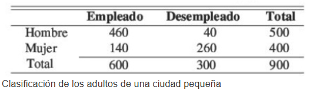

¿Cuál es la probabilidad de seleccionar un hombre, dado que el elegido tiene empleo?

# Ejercicio 2

Un jugador lanza dos dados con las caras numeradas del 1 al 6. La variable aleatoria $X$ se define como la suma de los números obtenidos en el lanzamiento.

1. ¿Cuál es el espacio muestral?
2. Determinar la distribución de probabilidades.
3. Calcular $P(X \geq 9)$

# Ejercicio 3

Dados los siguientes histogramas de densidad:

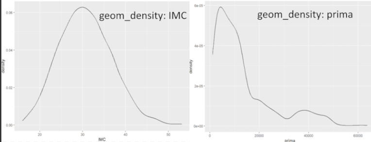

1. ¿Qué pude decir de las variables IMC y prima?
2. Describir los gráficos en términos de las medidas de forma.

# Ejercicio 4

Un estadístico determinó un intervalo de confianza del $95\%$ para la concentración media del zinc en un río, obtenido a partir de las mediciones en 36 sitos diferentes con media muestral de $2.6$ gramos por mililitro y desviación estándar poblacional de $0.3$ gramos por mililitro. Este intervalo es $[2.502;2.697]$.

Interpretar el resultado obtenido por el estadístico.

# Ejercicio 5

Un conjunto de datos incluye variables que miden diversas características socioeconómicas y demográficas de diferentes regiones de Suiza.

Un estadísitico tomó estos datos y construyó dos modelos de regresión lineal para explicar la variable output *Fertility*

1. ¿Cón qué modelo se queda? ¿por qué?
2. El modelo 2 tiene un $R^2= 0.6993476$. Comente todo lo relevante sobre el modelo. Ejemplo: cuál es el modelo, qué representa este $R^2$, cuáles son las variables input, etc.

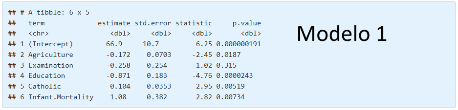

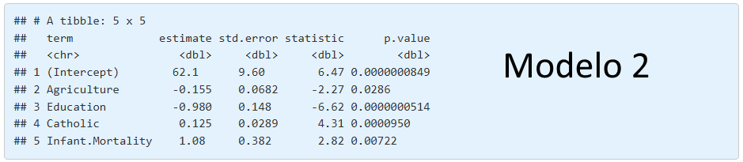